# UNIDAD PROFESIONAL INTERDISCIPLINARIA DE INGENIERÍA Y CIENCIAS SOCIALES ADMINISTRATIVAS

Fabián Ramírez Galindo

11 de enero de 2016

## Tarea 7

### Datos

**Se trabajara con el conjunto de datos obtenido en la tarea 6.**  
Los datos corresponden a la base de datos de eventos de tormentas (Storm Events Database). Se tomaron los datos del periodo 2000 a 2009. StormEvents_fatalities-ftp_v1.0_d2000_c20150826.csv  
StormEvents_fatalities-ftp_v1.0_d2001_c20150826.csv  
StormEvents_fatalities-ftp_v1.0_d2002_c20150826.csv  
StormEvents_fatalities-ftp_v1.0_d2003_c20150826.csv  
StormEvents_fatalities-ftp_v1.0_d2004_c20150826.csv  
StormEvents_fatalities-ftp_v1.0_d2005_c20150826.csv  
StormEvents_fatalities-ftp_v1.0_d2006_c20151230.csv  
StormEvents_fatalities-ftp_v1.0_d2007_c20151120.csv  
StormEvents_fatalities-ftp_v1.0_d2008_c20150826.csv  
StormEvents_fatalities-ftp_v1.0_d2009_c20151120.csv

### Sinopsis

En esta tarea se realizará el análisis de mortalidad por generado ocurrido en el periodo del 2000 a 2009. Se realizara un análisis por genero tomando la muestra de las muertes ocurridas en casa. En este caso nos centraremos en el mes de Septiembre del 2004.

### Desarrollo

Las columnas del conjunto de datos **Fatalities** son:

```
##  [1] "FAT_YEARMONTH"     "FAT_DAY"           "FAT_TIME"
##  [4] "FATALITY_ID"       "EVENT_ID"          "FATALITY_TYPE"
##  [7] "FATALITY_DATE"     "FATALITY_AGE"      "FATALITY_SEX"
## [10] "FATALITY_LOCATION" "EVENT_YEARMONTH"
```

El número de registros del conjunto de datos son:

```r
nrow(Fatalities)
```

```
## [1] 6341
```

Resumen del conjunto de datos **Fatalities**.

```r
summary(Fatalities)
```

```
##  FAT_YEARMONTH       FAT_DAY         FAT_TIME       FATALITY_ID
##  Min.   :200001   Min.   : 1.00   Min.   :   0.0   Min.   :      2
##  1st Qu.:200306   1st Qu.: 9.00   1st Qu.:   0.0   1st Qu.:   4679
##  Median :200508   Median :18.00   Median :   0.0   Median :  19966
##  Mean   :200503   Mean   :17.26   Mean   : 173.4   Mean   : 237373
##  3rd Qu.:200708   3rd Qu.:27.00   3rd Qu.:   0.0   3rd Qu.:  22004
##  Max.   :200912   Max.   :31.00   Max.   :1200.0   Max.   :1008716
##
##     EVENT_ID       FATALITY_TYPE             FATALITY_DATE
##  Min.   :    445   D:5682        08/28/2005 11:00:00: 982
##  1st Qu.: 147054   I: 659        02/05/2008 00:00:00:  54
##  Median :5299079                 05/04/2003 12:00:00:  36
##  Mean   :3610524                 11/10/2002 12:00:00:  34
##  3rd Qu.:5475620                 09/13/2008 00:00:00:  34
##  Max.   :5535195                 08/03/2006 12:00:00:  31
##                                  (Other)            :5170
##   FATALITY_AGE    FATALITY_SEX             FATALITY_LOCATION
##  Min.   :  0.00   F   :2199    Vehicle/Towed Trailer:1340
##  1st Qu.: 32.00   M   :4037    Other                :1182
##  Median : 51.00   NA's: 105    Permanent Home       :1093
##  Mean   : 50.36                Outside/Open Areas   :1062
##  3rd Qu.: 70.00                In Water             : 785
##  Max.   :102.00                Mobile/Trailer Home  : 372
##  NA's   :408                   (Other)              : 507
##  EVENT_YEARMONTH
##  Min.   :200001
##  1st Qu.:200305
##  Median :200508
##  Mean   :200498
##  3rd Qu.:200707
##  Max.   :200912
##  NA's   :77
```

Subconjunto sexo femenino del conjunto total de muertes en el periodo del 2000 a 2009.

```r
siteF <- unique(subset(Fatalities, FATALITY_SEX == "F", c(FAT_YEARMONTH, FAT_DAY,FAT_TIME,FATALITY_ID,EVENT_ID,FATALITY_TYPE,FATALITY_DATE,FATALITY_AGE,FATALITY_SEX,FATALITY_LOCATION,EVENT_YEARMONTH)))
```

Subconjunto sexo masculino del conjunto total de muertes en el periodo del 2000 a 2009.

```r
siteM <- unique(subset(Fatalities, FATALITY_SEX == "M", c(FAT_YEARMONTH, FAT_DAY,FAT_TIME,FATALITY_ID,EVENT_ID,FATALITY_TYPE,FATALITY_DATE,FATALITY_AGE,FATALITY_SEX,FATALITY_LOCATION,EVENT_YEARMONTH)))
```

Muertes del sexo femenino presentadas en casa.

```r
site0 <- unique(subset(siteF, FATALITY_LOCATION == "Permanent Home", c(FAT_YEARMONTH, FAT_DAY)))
```

Muertes del sexo masculino presentadas en casa.

```r
site1 <- unique(subset(siteM, FATALITY_LOCATION == "Permanent Home", c(FAT_YEARMONTH, FAT_DAY)))
```

```r
site0 <- paste(site0[,1], site0[,2], sep = ".")
site1 <- paste(site1[,1], site1[,2], sep = ".")
```

```r
str(site0)
```

```
##  chr [1:285] "200008.7" "200008.29" "200008.20" "200009.1" ...
```

```r
str(site1)
```

```
##  chr [1:330] "200008.3" "200008.29" "200008.30" "200008.24" ...
```

Intersección de muertes masculinas y femeninas presentadas en la misma fecha.

```r
both <- intersect(site0, site1)
print(both)
```

```
##   [1] "200008.29" "200008.20" "200009.1"  "200009.2"  "200009.3"
##   [6] "200002.14" "200007.18" "200007.14" "200007.12" "200007.23"
##  [11] "200007.22" "200007.9"  "200007.6"  "200007.21" "200008.19"
##  [16] "200008.8"  "200005.8"  "200005.12" "200006.14" "200007.19"
##  [21] "200007.16" "200006.25" "200007.8"  "200106.17" "200107.24"
##  [26] "200106.18" "200108.1"  "200106.11" "200108.2"  "200108.8"
##  [31] "200108.9"  "200108.10" "200108.3"  "200107.21" "200108.7"
##  [36] "200108.11" "200111.24" "200106.30" "200106.9"  "200107.18"
##  [41] "200107.22" "200107.23" "200107.31" "200107.7"  "200107.10"
##  [46] "200102.24" "200206.25" "200207.16" "200207.3"  "200207.4"
##  [51] "200207.5"  "200207.29" "200207.30" "200207.6"  "200207.9"
##  [56] "200208.5"  "200208.2"  "200206.27" "200207.1"  "200207.17"
##  [61] "200204.28" "200208.3"  "200208.1"  "200208.18" "200208.20"
##  [66] "200211.10" "200207.8"  "200301.24" "200306.26" "200308.27"
##  [71] "200305.4"  "200410.18" "200409.18" "200401.2"  "200405.29"
##  [76] "200409.16" "200409.15" "200507.25" "200507.26" "200509.24"
##  [81] "200509.25" "200509.26" "200512.15" "200501.6"  "200501.10"
##  [86] "200507.18" "200507.22" "200507.27" "200507.23" "200501.29"
##  [91] "200603.9"  "200603.12" "200604.7"  "200604.2"  "200607.25"
##  [96] "200607.23" "200607.27" "200607.20" "200607.30" "200607.19"
## [101] "200608.2"  "200608.3"  "200608.5"  "200608.1"  "200608.4"
## [106] "200609.1"  "200607.18" "200607.16" "200612.19" "200612.4"
## [111] "200612.5"  "200712.20" "200703.1"  "200703.28" "200706.19"
## [116] "200702.27" "200708.12" "200708.6"  "200708.10" "200705.4"
## [121] "200709.4"  "200710.22" "200712.3"  "200712.2"  "200801.23"
## [126] "200805.10" "200806.11" "200802.5"  "200805.2"  "200812.13"
## [131] "200812.5"  "200806.10" "200806.12" "200805.25" "200803.15"
## [136] "200802.6"  "200809.13" "200809.2"  "200809.1"  "200809.15"
## [141] "200809.14" "200906.27" "200906.29" "200906.25" "200904.9"
## [146] "200901.29" "200901.27"
```

```r
siteF$Fatdate<- with(siteF, paste(FAT_YEARMONTH, FAT_DAY, sep = "."))
siteM$Fatdate <- with(siteM, paste(FAT_YEARMONTH, FAT_DAY, sep = "."))
```

```r
cnt0 <- subset(siteF, FATALITY_LOCATION == "Permanent Home" & Fatdate%in% both)
cnt1 <- subset(siteM, FATALITY_LOCATION == "Permanent Home" & Fatdate%in% both)
```

```r
sapply(split(cnt0, cnt0$Fatdate), nrow)
```

```
## 200002.14 200005.12  200005.8 200006.14 200006.25 200007.12 200007.14
##         1         1         2         5         1         1         2
## 200007.16 200007.18 200007.19 200007.21 200007.22 200007.23  200007.6
##         1         3         1         2         1         2         1
##  200007.8  200007.9 200008.19 200008.20 200008.29  200008.8  200009.1
##         1         1         1         1         2         2         1
##  200009.2  200009.3 200102.24 200106.11 200106.17 200106.18 200106.30
##         1         1         2         1         1         1         1
##  200106.9 200107.10 200107.18 200107.21 200107.22 200107.23 200107.24
##         1         2         2         1         2         1         1
## 200107.31  200107.7  200108.1 200108.10 200108.11  200108.2  200108.3
##         1         1         1         6         1         1         1
##  200108.7  200108.8  200108.9 200111.24 200204.28 200206.25 200206.27
##         1         9         5         3         1         2         2
##  200207.1 200207.16 200207.17 200207.29  200207.3 200207.30  200207.4
##         1         2         1         2         3         2         4
##  200207.5  200207.6  200207.8  200207.9  200208.1 200208.18  200208.2
##         9         1         1         2         1         1         2
## 200208.20  200208.3  200208.5 200211.10 200301.24  200305.4 200306.26
##         2         1         1         3         2         9         2
## 200308.27  200401.2 200405.29 200409.15 200409.16 200409.18 200410.18
##         1         1         2         4         8         1         1
## 200501.10 200501.29  200501.6 200507.18 200507.22 200507.23 200507.25
##         6         1         1         2         1         1         1
## 200507.26 200507.27 200509.24 200509.25 200509.26 200512.15 200603.12
##         1         2         3         1         2         1         2
##  200603.9  200604.2  200604.7 200607.16 200607.18 200607.19 200607.20
##         1         8         1         1         1         2         4
## 200607.23 200607.25 200607.27 200607.30  200608.1  200608.2  200608.3
##         1         2         3         1         1         4         6
##  200608.4  200608.5  200609.1 200612.19  200612.4  200612.5 200702.27
##         2         2         1         1         1         1         1
##  200703.1 200703.28  200705.4 200706.19 200708.10 200708.12  200708.6
##         2         1         3         2         2         1         1
##  200709.4 200710.22  200712.2 200712.20  200712.3 200801.23  200802.5
##         1         1         1         3         1         1        10
##  200802.6 200803.15 200805.10  200805.2 200805.25 200806.10 200806.11
##         2         1         3         2         3         4         6
## 200806.12  200809.1 200809.13 200809.14 200809.15  200809.2 200812.13
##         1         2         3         2         2         1         1
##  200812.5 200901.27 200901.29  200904.9 200906.25 200906.27 200906.29
##         1         3         1         2         1         1         1
```

```r
sapply(split(cnt1, cnt1$Fatdate), nrow)
```

```
## 200002.14 200005.12  200005.8 200006.14 200006.25 200007.12 200007.14
##         1         1         2         2         1         1         3
## 200007.16 200007.18 200007.19 200007.21 200007.22 200007.23  200007.6
##         5         2         2         2         2         1         1
##  200007.8  200007.9 200008.19 200008.20 200008.29  200008.8  200009.1
##         1         3         1         1         2         1         1
##  200009.2  200009.3 200102.24 200106.11 200106.17 200106.18 200106.30
##         2         1         3         1         1         2         1
##  200106.9 200107.10 200107.18 200107.21 200107.22 200107.23 200107.24
##         1         1         1         2         3         3         3
## 200107.31  200107.7  200108.1 200108.10 200108.11  200108.2  200108.3
##         6         3         1         4         4         2         2
##  200108.7  200108.8  200108.9 200111.24 200204.28 200206.25 200206.27
##         2         8        10         1         1         3         2
##  200207.1 200207.16 200207.17 200207.29  200207.3 200207.30  200207.4
##         1         2         1         1         3         2         7
##  200207.5  200207.6  200207.8  200207.9  200208.1 200208.18  200208.2
##         4         2         2         4         1         2         2
## 200208.20  200208.3  200208.5 200211.10 200301.24  200305.4 200306.26
##         1         2         2         5         1        10         2
## 200308.27  200401.2 200405.29 200409.15 200409.16 200409.18 200410.18
##         1         1         1         2         6         1         2
## 200501.10 200501.29  200501.6 200507.18 200507.22 200507.23 200507.25
##         4         1         1         3         1         1         2
## 200507.26 200507.27 200509.24 200509.25 200509.26 200512.15 200603.12
##         1         1         2         1         1         1         9
##  200603.9  200604.2  200604.7 200607.16 200607.18 200607.19 200607.20
##         1         8         2         1         4         3         2
## 200607.23 200607.25 200607.27 200607.30  200608.1  200608.2  200608.3
##         3         4         8         3         6        12         9
##  200608.4  200608.5  200609.1 200612.19  200612.4  200612.5 200702.27
##        11         2         1         4         1         1         1
##  200703.1 200703.28  200705.4 200706.19 200708.10 200708.12  200708.6
##         1         1         4         1         1         1         3
##  200709.4 200710.22  200712.2 200712.20  200712.3 200801.23  200802.5
##         1         1         1         2         1         1         8
##  200802.6 200803.15 200805.10  200805.2 200805.25 200806.10 200806.11
##         3         1         1         1         4         3         4
## 200806.12  200809.1 200809.13 200809.14 200809.15  200809.2 200812.13
##         1         2         1         3         4         2         1
##  200812.5 200901.27 200901.29  200904.9 200906.25 200906.27 200906.29
##         1         2         2         2         2         1         1
```

Se obtendra el número de muertes ocurridas en Septiembre del 2004.

```r
both.FAT_YEARMONTH<-200409
```

```r
siteFsub <- subset(siteF, FATALITY_LOCATION == "Permanent Home" & FAT_YEARMONTH == both.FAT_YEARMONTH)
siteMsub <- subset(siteM, FATALITY_LOCATION == "Permanent Home" & FAT_YEARMONTH == both.FAT_YEARMONTH)
```

Las edades de las mujeres fallecidas son:

```r
AgeF<- as.character(siteFsub$FATALITY_AGE)
print(AgeF)
```

```
##  [1] NA   "86" "71" "52" "82" "54" "49" "77" "35" "37" "77" "35" "37" "47"
## [15] "91"
```

Las edades de los hombres fallecidos son:

```r
AgeM<- as.character(siteMsub$FATALITY_AGE)
print(AgeM)
```

```
##  [1] NA   "78" "53" "3"  "57" "55" "81" "55" "41" "55" "41"
```

```r
xFsub <- siteFsub$FAT_DAY
xMsub <- siteMsub$FAT_DAY
```

Obtener el valor mínimo y máximo de los dos conjuntos

```r
rng <- range(xFsub, xMsub, na.rm = T)
```

Gráfica de datos de muertes de mujeres.

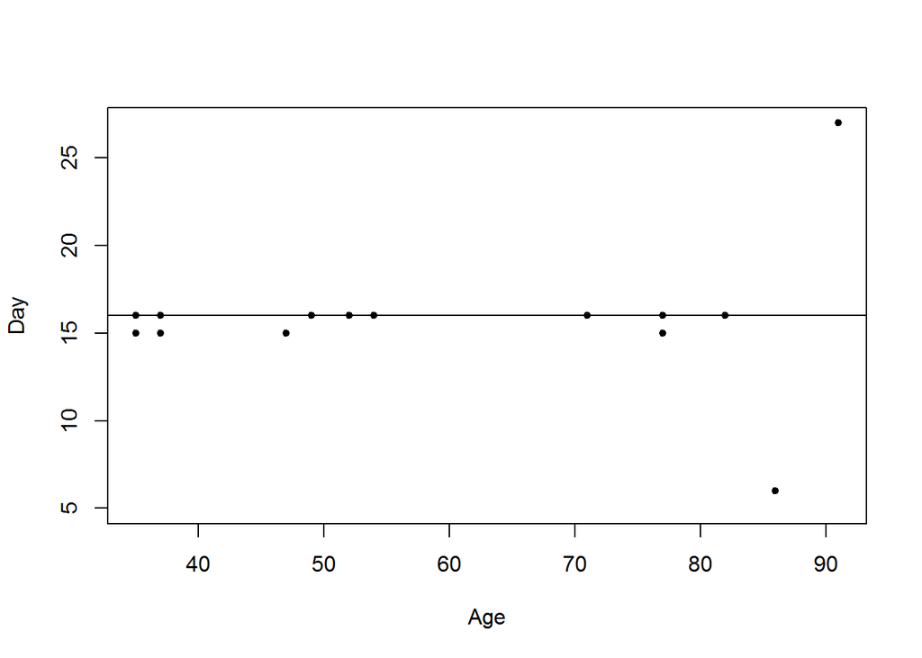

```r
plot(AgeF, xFsub, pch = 20, ylim = rng, xlab = "Age", ylab = "Day")
abline(h = median(xFsub, na.rm = T))
```

Gráfica de datos de muertes de hombres

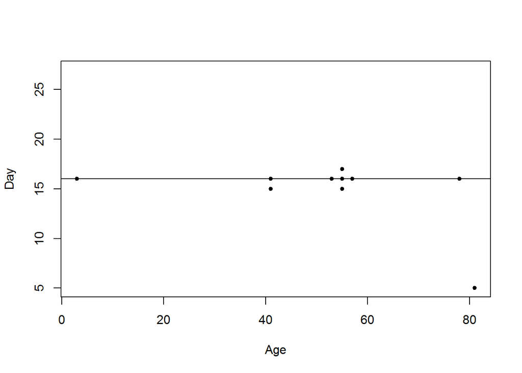

```r
plot(AgeM, xMsub, pch = 20, ylim = rng, xlab = "Age", ylab = "Day")
abline(h = median(xMsub, na.rm = T))
```

### Bibliografía

[1] Markdown & Pygments Lexers Cheat Sheet http://joedicastro.com/pages/markdown.html

[2] National Centers for Environmental Information http://www.ncdc.noaa.gov/stormevents